# Exercise One: Bar Charts

##### How to remove Highlighting and Axis Scaling

The Packages required to complete this exercise have been loaded in the answer sheet for you already. These include ggplot2, dplyr, DT, tools, RColorBrewer, readxl, reshape2, tidyR, scales, cowplot and a new library called PieBarViz. If you need to install these libraries uncomment the install packages function in the second cell of the notebook to install them all. This first page will demonstrate common visualisation errors using bar charts including Highlighting and Axis Scaling that were demonstrate in the Bad Viz shiny app.

Bar graphs are perhaps the most commonly used kind of data visualization. They’re typically used to display numeric values (on the y-axis), for different categories (on the x-axis). As an initial visualisation exercise, you need fix the given bad visualisation. The data being used is stored in a dataframe `ExerciseOne`.

##### Data

|  | Model | Accuracy |
| --- | --- | --- |
| 1 | Their Model 1 | 0.589415 |
| 2 | Their Model 2 | 0.590705 |
| 3 | Our Model 1 | 0.590867 |
| 4 | Our Model 2 | 0.592849 |

##### The Initial Visualisation

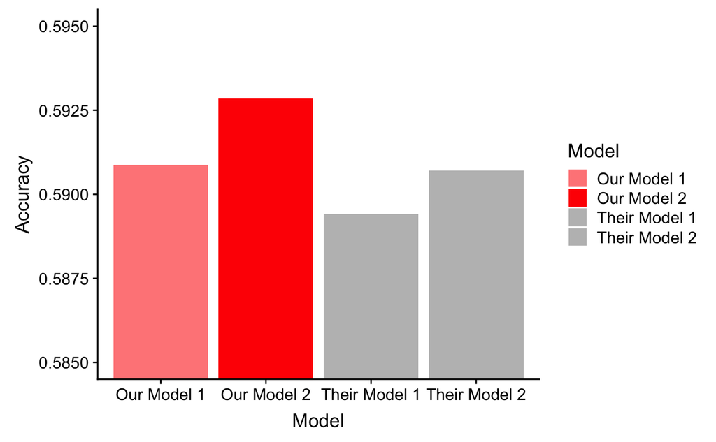

```r
  ggplot(data = ExerciseOne, aes(x = Model, y = Accuracy, fill = Model)) + geom_bar(stat ="identity") +
        coord_cartesian(ylim = c(0.585, 0.595)) +
  scale_fill_manual(values = c("#FF8888", "#FF0000", "Gray", "Gray"))
```

Your task is to update the ggplot2 code for the bar graph to remove the two misleading factors in this visualisation:

**Open the notebook in RStudio and replace the dashes with the correct answer. For more information on scale_fill_manual and coord_cartesian visit the links below**

https://ggplot2.tidyverse.org/reference/scale_manual.html

https://ggplot2.tidyverse.org/reference/coord_cartesian.html

```r
  # ggplot(data = ExerciseOne, aes(x = Model, y = Accuracy, fill = Model)) + geom_bar(stat ="identity") +
  #       coord_cartesian(ylim = c(---, ---)) +
  # scale_fill_manual(values = c(---, ---, ---, ---))
```

If your rendered plot looks similar to the plot below, you have successfully created a visualisation that does not mislead your audience.

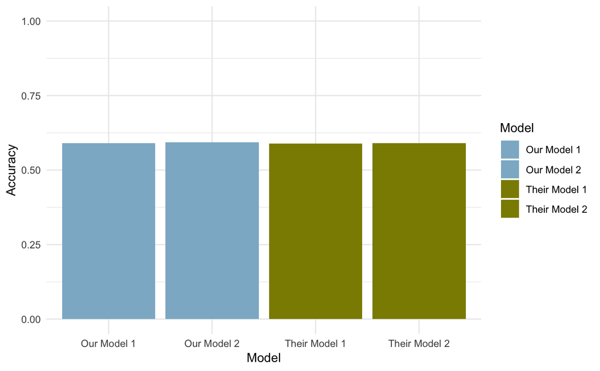